# Ejercicio Árbol Gender Discrimination

# modelo a estimar Gender ~ Experience + Salary

### 1- Instalar y cargar librerías necesarias para el ejercicio

```r
#install.packages("tree")
library(tree)
#install.packages("rpart")
library(rpart)
#install.packages("rpart.plot")
library(rpart.plot)
#install.packages("partykit")
library(partykit)
#install.packages("party")
library(party)
```

### 2- Establecer Work Directory.

Establecemos un work directory el cual contiene el documento csv que vamos a utilizar para la estimación del modelo.

A partir de esto, vamos a definir un DataFrame (al que llamaremos “gender”“) de las 208 observaciones de tres variables: sexo (Gender), años de experiencia (Experience) y salario (Salary).

Hacemos un head(), para que nos muestre los primeros y así observar que se han descargado correctamente.

```r
setwd("C:/Users/jorge/Desktop/JORGE/CUNEF/MASTER/TECNICAS DE CLASIFICACION/Clase03/Practica arbol decision/Ejercicio Gender Discrimination")

gender <- read.csv("http://www.biz.uiowa.edu/faculty/jledolter/DataMining/GenderDiscrimination.csv")

head(gender, 6) # comprobamos el encabezado de gender
```

```
##   Gender Experience Salary
## 1 Female         15  78200
## 2 Female         12  66400
## 3 Female         15  61200
## 4 Female          3  61000
## 5 Female          4  60000
## 6 Female          4  68000
```

```r
attach(gender)
```

### 3- Variable a estimar (Gender)

La variable a estimar será el sexo en función de los años de experiencia y el salario.

Previo a estimar el modelo, determinaremos el número de hombres y mujeres del DataFrame. Para una mejor visualización lo haremos mediante un histograma.

El resultado nos indica que dentro de nuestro DataFrame hay 140 mujeres y 68 hombres.

```r
sum(gender$Gender=="Female")
```

```
## [1] 140
```

```r
sum(gender$Gender=="Male")
```

```
## [1] 68
```

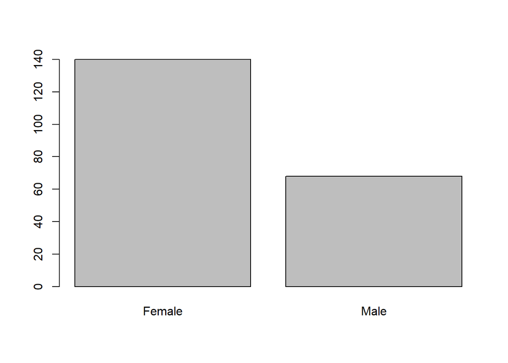

```r
plot(gender$Gender)
```

### 4- Muestra de entrenamiento y validación

#### 4.1- Definimos semilla aleatoria.

```r
set.seed((124))
```

#### 4.2- Muestra aleatoria de aprendizaje del árbol

Definimos una muestra aleatoria de aprendizaje del árbol, esta será el 70% de los datos que tenemos en el DataFrame:

```r
train <- sample(nrow(gender), 0.7*nrow(gender))
par(mfrow=c(1,2))
```

#### 4.3- Muestra de entrenamiento (70%)

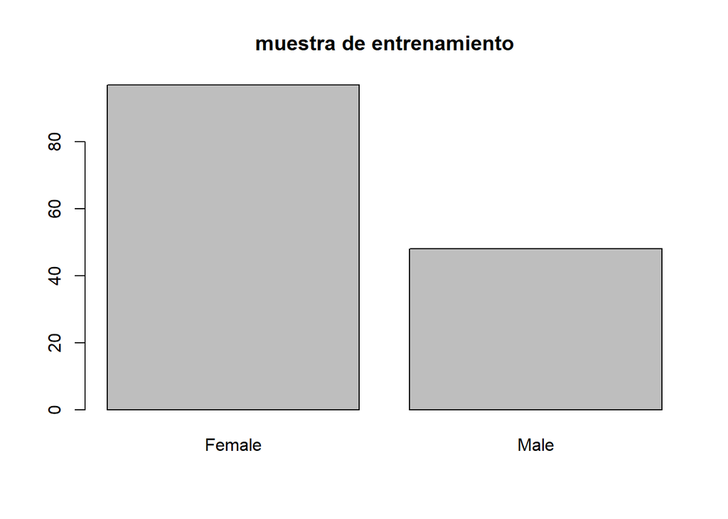

```r
gender.train <- gender[train,]
plot(gender.train$Gender, main="muestra de entrenamiento")
```

#### 4.4- Muestra de validación (30%)

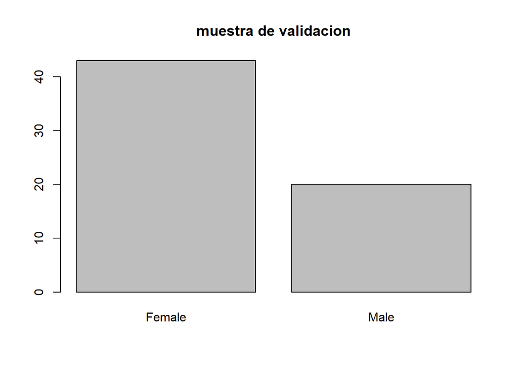

```r
gender.validate <- gender[-train,]
plot(gender.validate$Gender, main="muestra de validacion")
```

### 5- Creamos árbol de clasificación

Primero vamos a crear el árbol de clasificación con todos los nodos posibles:

```r
arbol <- rpart(Gender~ ., data=gender.train,method="class", parms=list(split="information"))

print(arbol)
```

```
## n= 145
##
## node), split, n, loss, yval, (yprob)
##       * denotes terminal node
##
##  1) root 145 48 Female (0.6689655 0.3310345)
##    2) Salary< 90800 119 30 Female (0.7478992 0.2521008)
##      4) Experience>=6.5 89 14 Female (0.8426966 0.1573034) *
##      5) Experience< 6.5 30 14 Male (0.4666667 0.5333333)
##       10) Salary< 60950 7  1 Female (0.8571429 0.1428571) *
##       11) Salary>=60950 23  8 Male (0.3478261 0.6521739)
##         22) Experience< 4.5 9  4 Female (0.5555556 0.4444444) *
##         23) Experience>=4.5 14  3 Male (0.2142857 0.7857143) *
##    3) Salary>=90800 26  8 Male (0.3076923 0.6923077) *
```

Vamos a interpretar los datos de la siguiente manera:

1.) Se obtiene 145 observaciones donde el 66.89% son mujeres y el 33.11% son hombres

```
1.1) La condición salario<90800, nos indica que es cumplida por 119 observaciones: 74.79% mujeres y 25.21% son hombres.

  1.1.1) Años de experiencia igual o mayor a 6.5 años, es cumplido por 89 observaciones de las que el 84.27% son mujeres y el 15.73% son hombres.

  1.1.2) Años de experiencia menor a 6.5 años, es cumplido por 30 observaciones de las que el 46.67% son mujeres y el 53.33% son hombres.

    1.1.2.1) Dentro de estos últimos: La condición salario<60950, nos indica que es cumplida por 7 observaciones: 85.71% mujeres y 14.29% son hombres.

    1.1.2.2) 23 observaciones tienen un salario mayor o igual a 60950, de las que el 34.78% son mujeres y 65.22% son hombres.

      1.1.2.2.1) De estas 23 observaciones 9, tienen menos de 4.5 años de experiencia (55.55% mujeres y 44.45% hombres)

      1.1.2.2.2) 14 observaciones tienen una experiencia igual o superior a 4.5 años, de las que el 21.43% son mujeres y el 78.57% son hombres.

1.2) La condición salario>=90800, nos indica que es cumplida por 26 observaciones: 30.77% mujeres y 69.23% son hombres.
```

#### 5.1- Dibujamos el arbol.

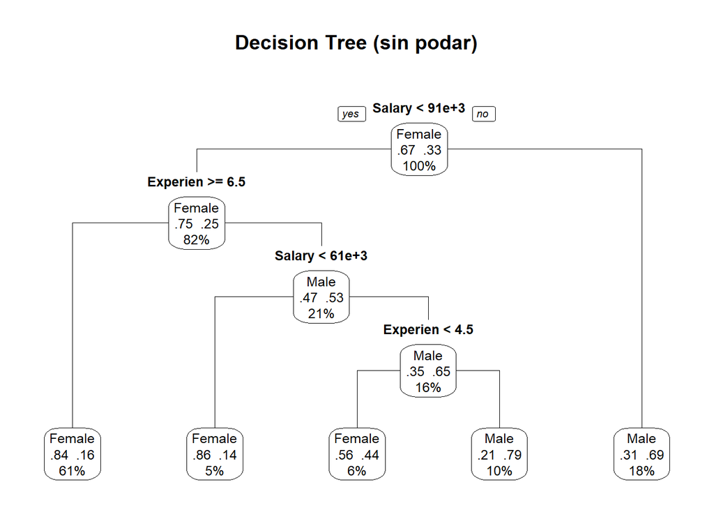

```r
prp(arbol, type = 1, extra = 104, fallen.leaves = TRUE, main="Decision Tree (sin podar)")
```

#### 5.2- Complejidad del árbol.

Dibujamos la gráfica con el CP asociado al menor error.

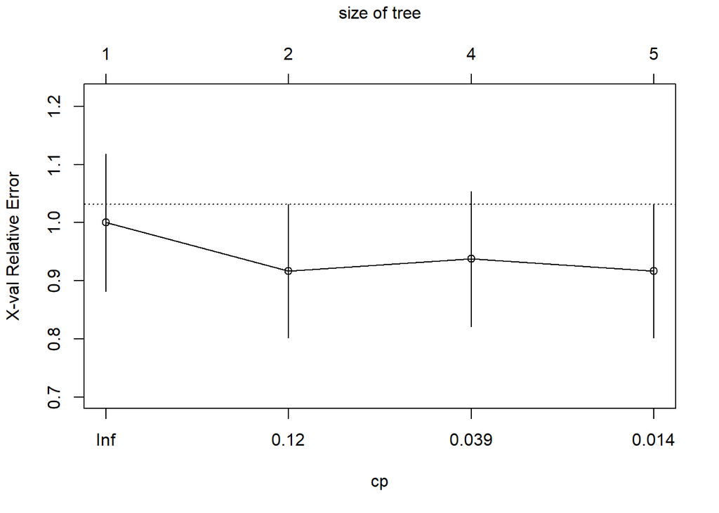

```r
plotcp(arbol)
```

Tabla de complejidades:

```r
arbol$cptable
```

```
##           CP nsplit rel error    xerror      xstd
## 1 0.20833333      0 1.0000000 1.0000000 0.1180541
## 2 0.07291667      1 0.7916667 0.9166667 0.1153352
## 3 0.02083333      3 0.6458333 0.9375000 0.1160596
## 4 0.01000000      4 0.6250000 0.9166667 0.1153352
```

### 6- Podamos el árbol de clasificación.

Por las conclusiones sacadas anteriormente, vamos a podar el árbol por el nodo 2:

Cogemos por xerror=0.9166667 y cp=0.07291667

```r
arbol.podado <- prune(arbol, cp=0.07291667)
arbol.podado
```

```
## n= 145
##
## node), split, n, loss, yval, (yprob)
##       * denotes terminal node
##
## 1) root 145 48 Female (0.6689655 0.3310345)
##   2) Salary< 90800 119 30 Female (0.7478992 0.2521008) *
##   3) Salary>=90800 26  8 Male (0.3076923 0.6923077) *
```

#### 6.1- Dibujamos el árbol

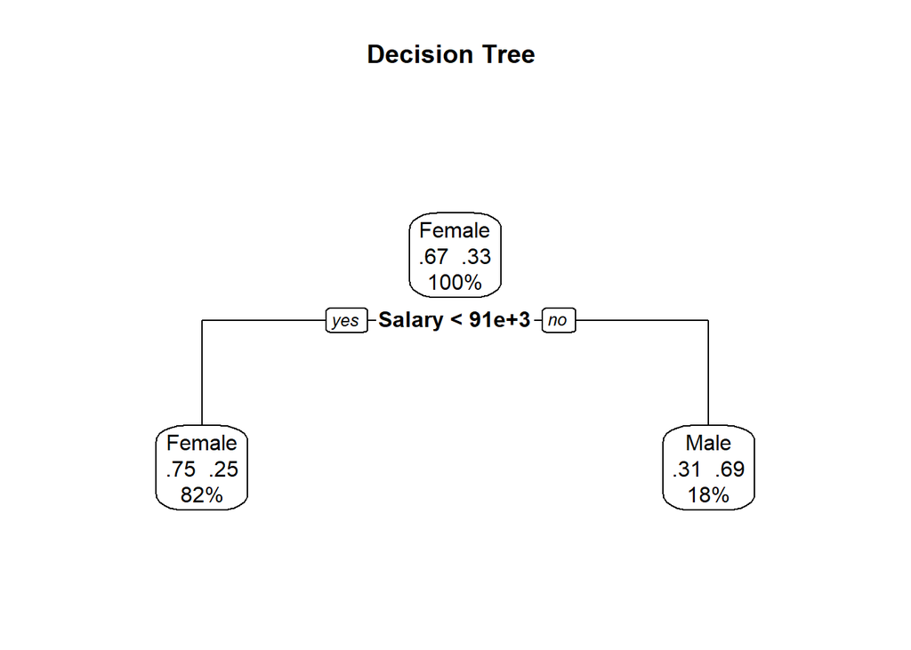

```r
prp(arbol.podado, type = 2, extra = 104, fallen.leaves = TRUE, main="Decision Tree ")
```

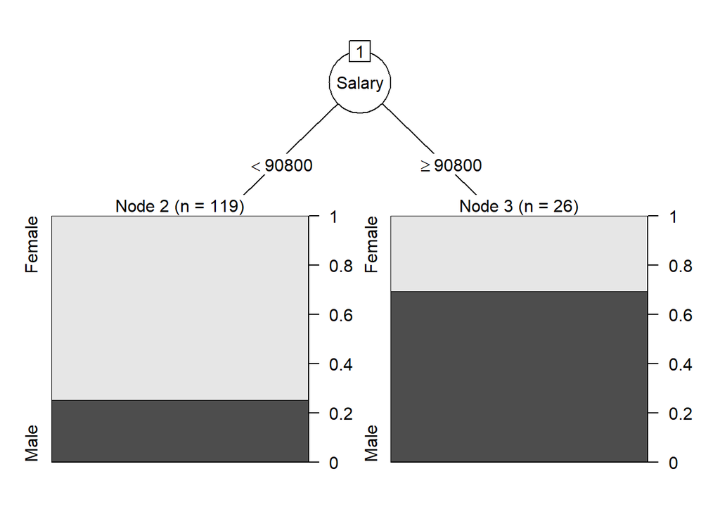

```r
#Otra forma de graficarlo.
plot(as.party(arbol.podado))
```

### 7- Comprobación.

Una vez realizado el árbol con la muestra de entrenamiento, vamos a estimarlo con la muestra de validación para ver si está correctamente estimado.

#### 7.1- Árbol sin podar.

```r
arbol.pred <- predict(arbol, gender.validate, type="class")
arbol.perf <- table(gender.validate$Gender, arbol.pred, dnn=c("Actual", "Predicted"))
arbol.perf
```

```
##         Predicted
## Actual   Female Male
##   Female     32   11
##   Male       10   10
```

Con los resultados observamos que el modelo a predecido correctamente que el género era femenino para 32 casos y que el masculino para 10 casos.

Sin embargo, ha predecido mal 21 observaciones. Si en total había 63 observaciones en la muestra de validación, se ha estimado bien el 66.67% de las observaciones. (42/63)*100

#### 7.2- Árbol podado.

```r
arbol.pred <- predict(arbol.podado, gender.validate, type="class")
arbol.perf <- table(gender.validate$Gender, arbol.pred, dnn=c("Actual", "Predicted"))
arbol.perf
```

```
##         Predicted
## Actual   Female Male
##   Female     40    3
##   Male       11    9
```

Con los resultados observamos que el modelo podado a predecido correctamente que el género era femenino para 40 casos y que el masculino para 9 casos.

Sin embargo, ha predecido mal 14 observaciones. Si en total había 63 observaciones en la muestra de validación, se ha estimado bien el 77.78% de las observaciones. (49/63)*100.

### 8- Conclusiones.

El árbol podado, finalmente, observamos como ha hecho una mejor estimación del modelo con un porcentaje de 77.78% frente a un porcentaje de 66.67% del árbol sin podar.

Interpretando el árbol podado, observamos que la mayoría de las personas con un salario superior a 90800 euros son hombres.

Dentro de nuestro DataFrame, observamos que de los 68 hombres, 27 tienen un suelto mayor o igual 90800€ y únicamente 11 mujeres de las 140.